# GBSG subgroup analysis across selection foci: Naive, Full Bootstrap, Multiplier Resampling, and Guo & He

### 0.3.1 Identified subgroups and estimates

```r
res_tabs <- sg_tables(fs, ndecimals = 3, which_df = "est")
res_tabs$sg10_out
```

**Identified Subgroups**

Two-factor subgroups (maxk=2)

| Factor 1 | Factor 2 | N | Events | E<sub>1</sub> | HR | P<sub>cons</sub> |
| --- | --- | --- | --- | --- | --- | --- |
| {er <= 0} | {size <= 35} | 61 | 34 | 15 | 2.537 | 0.990 |
| {er <= 0} | {nodes <= 7} | 61 | 31 | 11 | 2.335 | 0.970 |
| {er <= 0} |  | 82 | 45 | 16 | 1.951 | 0.960 |
| {er <= 0} | {pgr <= 26} | 75 | 41 | 16 | 2.222 | 0.990 |
| {pgr <= 0} | {er <= 9} | 71 | 42 | 16 | 1.684 | 0.900 |
| {er <= 0} | {pgr <= 16} | 70 | 38 | 14 | 1.918 | 0.950 |
| {er <= 0} | {pgr <= 8} | 66 | 35 | 14 | 2.129 | 0.970 |
| {er <= 0} | {pgr <= 2} | 62 | 34 | 13 | 1.886 | 0.920 |
| {er <= 0} | !{size <= 20} | 61 | 35 | 12 | 2.054 | 0.950 |

**Search Configuration:** Single-factor candidates (L) = 66; Maximum combinations evaluated = 2,211; Search depth (maxk) = 2  
**Search Results:** Candidate subgroups found = 121; Maximum HR estimate = 2.54  
**Note:** E<sub>1</sub> = events in treatment arm; P<sub>cons</sub> = consistency proportion

```r
res_tabs$tab_estimates
```

**Treatment Effect Estimates**

Training data estimates

| Subgroup | n | n1 | events | m1 | m0 | RMST | HR (95% CI) |
| --- | --- | --- | --- | --- | --- | --- | --- |
| ITT | 686 (100.0%) | 246 (35.9%) | 299 (43.6%) | 66.3 | 50.2 | 7.8 | 0.69 (0.54, 0.89) |
| Questionable<sup>1</sup> | 61 (8.9%) | 23 (37.7%) | 34 (55.7%) | 18.5 | 48 | -19 | 2.54 (1.25, 5.17) |
| Recommend | 625 (91.1%) | 223 (35.7%) | 265 (42.4%) | 66.7 | 52.2 | 9.6 | 0.61 (0.47, 0.79) |

<sup>1</sup> **Identified subgroup:** {er <= 0} & {size <= 35}

```r
cat("Identified subgroup (H):", paste(fs$sg.harm, collapse = " & "), "\n")
```

```
#> Identified subgroup (H): {er <= 0} & {size <= 35}
```

```r
cat("Subgroup size:", sum(fs$df.est$treat.recommend == 0),
    sprintf("(%.1f%% of ITT)\n",
            100 * mean(fs$df.est$treat.recommend == 0)))
```

```
#> Subgroup size: 61 (8.9% of ITT)
```

## 0.4 Selection diagnostic: Pareto frontier

The *Pareto frontier* on (effect, N) is the set of candidate subgroups not dominated on both axes simultaneously: a candidate is dominated when another has at least as large an effect **and** at least as large a sample size, with at least one strict inequality.

For `sg_focus = "effMaxSG"` with `selection_rule = "neighborhood"`, this is not a post-hoc diagnostic – it is the selection geometry. `.compute_inclusion_band()` builds `in_nbhd` (effect within 10% of the strongest surviving effect) and `in_pareto` (non-dominated), and the rule uses the effect band alone. The `in_band` indicator then **leads** the sort key (-in_band, -N, -Pcons, -hr, K), so what the figure and table below display is the space the rule actually chose within.

```r
# Split-derived CIs for the frontier members.  This is the expensive step; the
# same intervals feed the figure, the table and the narrative, so it is
# computed once.  Set frontier_params$compute_cis <- FALSE to skip.
t0 <- proc.time()
ci_tab <- if (isTRUE(frontier_params$compute_cis)) {
  compute_frontier_cis(
    fs,
    n_splits = frontier_params$n_splits,
    seed     = frontier_params$seed
  )
} else {
  NULL
}
timings$frontier <- (proc.time() - t0)[["elapsed"]]
cat("Frontier CIs:", if (is.null(ci_tab)) "skipped" else
      sprintf("%d member(s) over %s splits in %.1f s",
              nrow(ci_tab), format(frontier_params$n_splits, big.mark = ","),
              timings$frontier), "\n")
```

```
#> Frontier CIs: 3 member(s) over 1,000 splits in 10.3 s
```

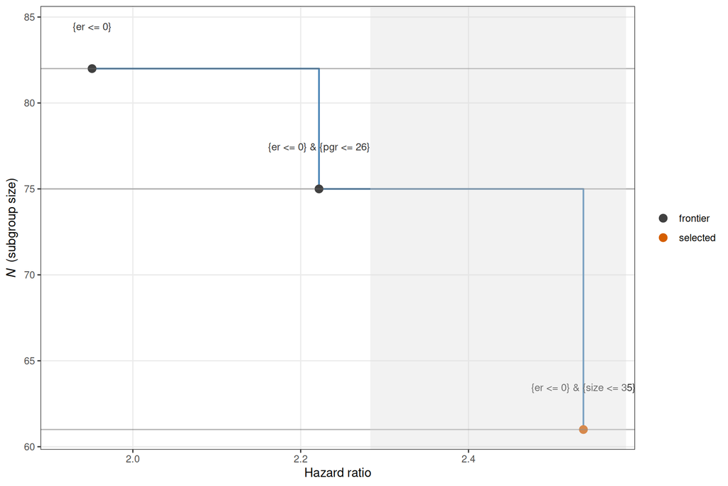

Pareto frontier on (effect, N). The shaded region is the effect-size inclusion band; the selected subgroup is marked. Horizontal bars are split-derived intervals when computed.

```r
p_pareto <- plot_pareto_frontier(
  fs,
  ci_table            = ci_tab,
  show_band           = TRUE,
  effect_neighborhood = focus$effect_neighborhood,
  xlim                = frontier_params$xlim,
  xlim_trim           = frontier_params$xlim_trim
)
print(p_pareto)
```

```r
# Formatted gt table; the selected subgroup is highlighted and marked with a
# star.  Effect column label and scale derive from fs$effect_measure, so the
# same call serves survival (HR) and GLM (OR, IRR, MD, ...) outcomes.
pareto_frontier_table(
  fs,
  ci_table = ci_tab,
  digits   = frontier_params$digits
)
```

Pareto frontier on (HR, N)

3 non-dominated candidate(s) | sg_focus = 'hrMaxSG' | HR shown on natural scale | diagnostic only

| S<sup>1,2</sup> | M.1 | M.2 | N | E | HR | P<sup>3</sup> | K | 95% CIs Naive | 95% CIs Split ~ | 95% CIs FSBC ~ |
| --- | --- | --- | --- | --- | --- | --- | --- | --- | --- | --- |
| ★ | {er <= 0} | {size <= 35} | 61 | 34 | 2.54 | 0.99 | 2 | (1.25, 5.17) | (1.10, 5.87) | 2.43 (1.05, 5.62) |
|  | {er <= 0} | {pgr <= 26} | 75 | 41 | 2.22 | 0.99 | 2 | (1.17, 4.22) | (1.05, 4.71) | 2.16 (1.02, 4.58) |
|  | {er <= 0} |  | 82 | 45 | 1.95 | 0.96 | 1 | (1.04, 3.67) | (0.95, 4.01) | 1.92 (0.94, 3.95) |

<sup>1</sup> S: selected subgroup (winner of the configured selection rule).  
<sup>2</sup> ★ marks the subgroup chosen by sg_focus = 'hrMaxSG'.  
<sup>3</sup> P: Pcons (consistency probability).

```r
# Narrative comparison of the winner against each non-dominated alternative,
# phrased in terms of the focus's own lexicographic key.
cat(explain_pareto_selection(fs, ci_table = ci_tab,
                             digits = frontier_params$digits))
```

**Selection criterion.** The configured criterion is largest-N within the effect-size band (sg_focus = “hrMaxSG”) under the effect-size neighborhood rule. The effect-size band requires hazard ratio within 10% of the maximum on the frontier (i.e., hazard ratio >= 2.28). Within the eligible set, ties on N are broken by Pcons, then by effect strength, then by parsimony (smaller K).

**Selected subgroup.** {er <= 0} AND {size <= 35} (hazard ratio = 2.54, N = 61, Pcons = 0.99, K = 2). This is the largest-N candidate in the eligible set among non-dominated frontier candidates. The Naive 95% CI for the hazard ratio on this subgroup is (1.25, 5.17).

**Non-selected frontier candidates** (ordered by closeness to winning):

- **{er <= 0} AND {pgr <= 26}** (hazard ratio = 2.22, N = 75, Pcons = 0.99, K = 2). fell outside the effect-size band (hazard ratio = 2.22 below the floor); excluded before the N tiebreaker even applies.
- **{er <= 0}** (hazard ratio = 1.95, N = 82, Pcons = 0.96, K = 1). fell outside the effect-size band (hazard ratio = 1.95 below the floor); excluded before the N tiebreaker even applies.

```r
# Programmatic access (effect on the natural scale, plus is_selected /
# on_frontier / in_band flags):
pareto_frontier_table(fs, format = "data.table", include_dominated = TRUE)
```

## 0.5 Full bootstrap (FB)

```r
t0 <- proc.time()
fs_bc <- forestsearch_bootstrap_dofuture(
  fs.est   = fs,
  nb_boots = NB,
  show_three = FALSE,
  details  = FALSE,
  parallel_args = list(plan = "multisession", workers = n_cores,
                       show_message = TRUE)
)
```

```
#> Bootstrap parallel config: Using user-provided settings
```

```
#> System max cores available: 128
```

```
#> Bootstrap will use: 102 workers with 'multisession' plan
```

```
#> Parallel plan: multisession with 102 workers.
```

```
#> Bootstrap iteration 1/1000
```

```
#> Bootstrap iteration 10/1000
```

```
#> Bootstrap iteration 50/1000
```

```
#> Bootstrap iteration 100/1000
```

```
#> Bootstrap iteration 250/1000
```

```
#> Bootstrap iteration 500/1000
```

```
#> Bootstrap iteration 750/1000
```

```
#> Bootstrap iteration 1000/1000
```

```r
plan("sequential")
timings$fb <- (proc.time() - t0)[["elapsed"]]

fb_sum <- summarize_bootstrap_results(
  sgharm = fs$sg.harm, boot_results = fs_bc,
  create_plots = FALSE, est.scale = "hr"
)
```

```
#>
#> ===============================================================
#>            BOOTSTRAP ANALYSIS SUMMARY
#> ===============================================================
#>
#> IDENTIFIED SUBGROUP:
#> -------------------------------------------------------------
#>   H: {er <= 0} & {size <= 35}
#>
#> BOOTSTRAP SUCCESS METRICS:
#> -------------------------------------------------------------
#>   Total iterations:              1000
#>   Successful subgroup ID:        976 (97.6%)
#>   Failed to find subgroup:       24 (2.4%)
#>
#> TIMING ANALYSIS:
#> -------------------------------------------------------------
#> Overall:
#>   Total bootstrap time:          1.15 minutes (0.02 hours)
#>   Average per iteration:         0.00 min (0.1 sec)
```

```r
cat("FB completed in", round(timings$fb / 60, 1), "min\n")
```

```
#> FB completed in 1.2 min
```

FB re-runs the **entire** selection on each resample, so it inherits whatever focus this render uses without any further configuration – and its cost scales with `NB`.

## 0.6 Multiplier resampling (MR)

The Tier-2 de-biased gate is the MR correction, computed inside the fit above (vectorized over 5,000 draws). It is read from `fs$mr_inference`; no separate run is needed.

MR re-selects under the same rule the search used. `sg_focus` is the single source of truth for that mapping, so the re-selection reported below should match this render’s focus rather than a default.

```r
g <- fs$mr_inference
stopifnot(!is.null(g))
timings$mr <- g$timing_seconds
cat("MR gate:", round(timings$mr, 2), "s over",
    format(mr_draws, big.mark = ","), "draws\n")
```

```
#> MR gate: 4.29 s over 5,000 draws
```

```r
cat("MR re-selection rule:", g$settings$reselection,
    sprintf("(search focus: %s / canonical %s)\n",
            focus$supplied, focus$canonical))
```

```
#> MR re-selection rule: effMaxSG (search focus: effMaxSG / canonical hrMaxSG)
```

```r
cat("Candidate family size:", g$n_family, "\n")
```

```
#> Candidate family size: 1744
```

```r
# Scale cross-check: the gate's naive HR and the bootstrap's naive H0 are the
# same quantity computed two ways.
.h0 <- tryCatch(as.numeric(fs_bc$H_estimates$H0), error = function(e) NA_real_)
if (is.finite(.h0) && is.finite(g$naive$est)) {
  cat(sprintf("Scale cross-check (MR naive vs FB H0): %s (%.3f vs %.3f)\n",
              if (abs(log(g$naive$est) - log(.h0)) < 1e-2) "PASS" else "CHECK",
              g$naive$est, .h0))
}
```

```
#> Scale cross-check (MR naive vs FB H0): PASS (2.537 vs 2.537)
```

## 0.7 Guo & He (GH)

*The Guo & He section is skipped for `sg_focus = "effMaxSG"`.*

This is a structural constraint rather than a configuration choice. `fs_to_guohe()` calls `fs_export_maxeff_family()`, which stops unless `fit$sg_focus == "maxeff"` (`fs_to_guohe.R:141-143`), and it materializes the **untruncated** deduplicated family that only `maxeff` guarantees (`max_subgroups_search -> Inf`).

The deeper reason is that Guo & He’s estimand is defined against the argmax primitive: their correction removes the winner’s-curse optimism of selecting the maximiser of an estimated effect. A rule that optimises **size** subject to an effect band is a different selection event, and their Theorems 4/5 say nothing about it. Running a second `maxeff` fit purely to obtain a comparator would report a correction for an estimator this document did not use, and pooling across foci silently mixes estimators.

Set `fs_sg_focus <- "maxeff"` for the head-to-head with MR.

```r
# The adapter exports the maxeff candidate family as membership columns and runs
# Guo & He Algorithm 3 on the SAME selected subgroup forestsearch chose.  The
# membership integrity check asserts that the exported selected-subgroup column
# matches forestsearch's own sg.harm.id exactly before the estimator runs.
t0 <- proc.time()
gh <- fs_to_guohe(
  fit       = fs,
  time      = "time_months", event = "status", treatment = "hormon",
  B         = GH_B, r = GH_r, level = 0.05, seed = 8316951,
  parallel  = GH_PARALLEL, verify = TRUE
)
timings$gh <- (proc.time() - t0)[["elapsed"]]

cat("GH family size:", length(gh$export$candidates),
    " | selected:", gh$selected,
    " | GH", round(timings$gh / 60, 1), "min\n")
cat(sprintf("GH  naive HR %.3f  debiased HR %.3f  lower bound %.3f\n",
            gh$naive_hr, gh$debiased_hr, gh$bound_hr))
```

## 0.8 Repeated 10-fold cross-validation (stability diagnostics)

Repeated 10-fold cross-validation partitions the data into ten folds, refits the selection on each nine-fold training set, and records which subgroup is identified – repeated over `Ksims` random partitions. It is a **stability diagnostic on the subgroup *definition***: across `Ksims` × 10 training splits, does the selection converge on a single dominant subgroup, or does it wander with the particular split?

This is a fixed-family analysis with no GRF, DINA or LASSO screens, so the GRF-specific fold diagnostics are omitted; the universal ones – identified- subgroup distribution, selected-candidate consistency, per-fold numerics, and agreement with the full-data selection – are reported.

```r
cat("> **10-fold CV skipped.** Set `run_cv_kfold <- TRUE` in the",
    "configuration to enable.\n")
```

```r
t0 <- proc.time()
fs_kfold <- forestsearch_tenfold(
  fs.est  = fs,
  sims    = Ksims,
  Kfolds  = 10,
  details = FALSE,
  parallel_args = list(plan = "multisession", workers = n_cores,
                       show_message = FALSE)
)
plan("sequential")
timings$kfold <- (proc.time() - t0)[["elapsed"]]
cat("10-fold CV:", Ksims, "x 10 partitions in",
    round(timings$kfold / 60, 1), "min\n")
```

```
#> 10-fold CV: 50 x 10 partitions in 0.5 min
```

```r
metrics_tables <- cv_metrics_tables(fs_kfold)
metrics_tables
```

**Cross-Validation Metrics**

Subgroup: Identified Subgroup

| Metric | Description | Value (%) |
| --- | --- | --- |
| Agreement |  |  |
| Sensitivity (H) | Agreement rate for subgroup H | 86.1 |
| Sensitivity (Hc) | Agreement rate for complement Hc | 96.0 |
| PPV (H) | Positive predictive value for H | 67.8 |
| PPV (Hc) | Positive predictive value for Hc | 98.6 |
| Subgroup Finding |  |  |
| Any Found | Any subgroup identified | 100.0 |
| Exact Match | Exact match on all factors | 0.0 |
| At Least 1 | At least one factor matches | 90.0 |
| Cov1 Any | First covariate found (any cut) | 90.0 |
| Cov2 Any | Second covariate found (any cut) | 0.0 |
| Cov1 & Cov2 | Both covariates found | 0.0 |
| Cov1 Exact | First covariate exact match | 90.0 |
| Cov2 Exact | Second covariate exact match | 0.0 |

Based on 50 simulation(s) with 10-fold CV. Values are medians shown as percentages.

### 0.8.1 Diagnostic tabulations

```r
cv_diag <- summarize_cv_results(
  cv_output    = fs_kfold,
  original_sg  = fs$sg.harm,
  top_n        = 10L,
  create_plots = TRUE
)
```

**Which subgroups emerged across resamples?** A single dominant subgroup with high share indicates the selection converges; a long tail indicates it is sensitive to the training split.

```r
cv_diag$identification_summary
```

**Identified subgroups across sim x fold pairs**

50 simulations x 10 folds = 500 total pairs

| Rank | Identified subgroup | n folds | % folds |
| --- | --- | --- | --- |
| 1 | {er <= 0} & {pgr <= 26} | 258 | 51.60 |
| 2 | {er <= 0} | 91 | 18.20 |
| 3 | {er <= 0} & {pgr <= 27} | 44 | 8.80 |
| 4 | {pgr <= 8} & {grade3} | 25 | 5.00 |
| 5 | {er <= 0} & {pgr <= 25} | 20 | 4.00 |
| 6 | (no subgroup) | 14 | 2.80 |
| 7 | {er <= 6} & !{meno} | 8 | 1.60 |
| 8 | {er <= 0} & {pgr <= 8} | 7 | 1.40 |
| 9 | {er <= 0} & {pgr <= 41} | 5 | 1.00 |
| 10 | {er <= 0} & {pgr <= 28} | 4 | 0.80 |
| 11 | (13 others) | 24 | 4.80 |

**How confidently were the successful identifications made?** Among folds that identified a subgroup, `pconsistency_distribution` shows where the selected candidate’s consistency probability landed.

Under a banded focus consistency is a **filter** at admission and then a third-tier key after `in_band` and size, so the distribution reflects both roles.

```r
cv_diag$pconsistency_distribution
```

**Pcons distribution among identifying folds**

Out of 500 sim x fold pairs

| Pcons range | n folds | % of identifying folds |
| --- | --- | --- |
| <0.5 | 0 | 0.00 |
| 0.5-0.7 | 0 | 0.00 |
| 0.7-0.8 | 0 | 0.00 |
| 0.8-0.85 | 0 | 0.00 |
| 0.85-0.95 | 73 | 15.02 |
| >=0.95 | 413 | 84.98 |
| Median (identifying): 0.980 | – | – |
| IQR (identifying): 0.960 - 0.990 | – | – |
| Identifying folds total | 486 | 97.20 |

Restricted to folds that identified a subgroup. A concentration near the pconsistency.threshold (typically 0.90) suggests many identifications are marginal; concentration above 0.95 suggests robust identifications. Values for rejected candidates are not surfaced -- only the selected candidate's Pcons is captured.

**How do the numeric fold-level diagnostics summarize?** Median / IQR / range for each numeric fold-level column: fold size (`n_test`), training-fold HR of the selected subgroup (`training_fs_hr`, in-sample and optimistically biased – for diagnostic comparison only), and candidate count (`n_candidates_evaluated`).

```r
cv_diag$fold_numeric_summary
```

**Fold-level numeric diagnostics**

Across 500 sim x fold pairs; per-metric denominator shown in Context

| Metric | n | Median | Q1 | Q3 | Min | Max | n NA | Context |
| --- | --- | --- | --- | --- | --- | --- | --- | --- |
| Test-fold size (n_test) | 500 | 69.000 | 68.000 | 69.000 | 68.000 | 69.000 | 0 | All sim x fold pairs |
| Pcons (identifying folds) | 486 | 0.980 | 0.960 | 0.990 | 0.900 | 1.000 | 14 | Folds that identified a subgroup |
| Training-fold subgroup effect (identifying folds) | 486 | 2.185 | 2.014 | 2.382 | 1.695 | 3.703 | 14 | Natural scale; in-sample; optimistically biased |
| Candidates evaluated per fold | 500 | 106.500 | 86.000 | 135.000 | 35.000 | 227.000 | 0 | Folds where consistency stage ran |

Training-fold subgroup effects are in-sample estimates on the effect measure's natural scale (HR for survival; OR, RR, IRR, RD, IRD, or MD for GLM). They are optimistically biased and shown here for diagnostic comparison across folds only; do not use for inference.

**Agreement with the full-data analysis.** How often does a training fold reproduce the original full-data subgroup exactly, or share a factor with it?

```r
cv_diag$original_agreement
```

**Agreement with original full-data analysis**

Fraction of sim x fold pairs matching the original result

|  | Value |
| --- | --- |
| Total sim x fold pairs | 500 |
| Original subgroup definition | {er <= 0} & {size <= 35} |
| Exact subgroup match | 0 (0.0%) |
| Partial match (>=1 shared factor) | 432 (86.4%) |

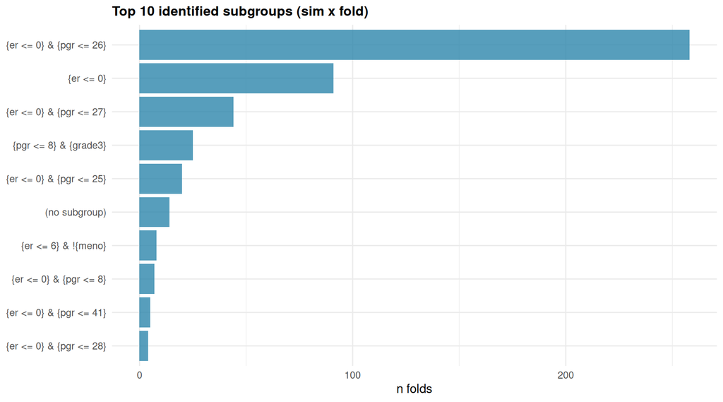

Distribution of identified subgroups across repeated 10-fold training splits.

```r
if (!is.null(cv_diag$plots) && !is.null(cv_diag$plots$identification)) {
  cv_diag$plots$identification
}
```

## 0.9 Leave-one-out (honest out-of-sample estimate)

Leave-one-out re-runs the entire selection on each hold-out of one subject and predicts the held-out subject’s subgroup membership from its covariates. It is an out-of-sample **stability check on the subgroup *definition***, not a de-biasing correction of the *effect*: it asks whether the same subgroup is recovered when no subject informs its own label. This is `forestsearch_Kfold()` at N-fold (`Kfolds = nrow(df)`).

How discriminating leave-one-out is depends on the focus. Under `effMaxSG` the key is (-in_band, -N, -Pcons, -hr, K). The band restricts the competition to near-optimal candidates and size then decides among them, which tends to make the definition steadier than a pure effect argmax: fold-to-fold movement requires the band membership or the size ordering to change, not merely the effect ranking.

Note this is the heaviest step: N-fold means one full forest search per subject. The fold loop is distributed across 102 workers; `parallel_args` controls **fold-level** parallelism only – each fold’s inner `forestsearch()` refit is pinned to `plan = "sequential"`, so there is no nested oversubscription – and the fold loop draws parallel-safe L’Ecuyer streams (`.options.future = list(seed = TRUE)`). In the frozen-family companion analysis the parallel fold loop was verified against a sequential run of the same analysis: identical per-subject predictions and an identical out-of-sample HR, at 5.2x the speed on 11 workers.

```r
cat("Leave-one-out skipped (run_loo = FALSE).",
    "Set run_loo <- TRUE in parallel-setup to run it.\n")
```

```r
# If a precomputed cv_out is available (LOO_CACHE env var, else the default
# path in gh_dir) load it; otherwise run the N-fold search and cache it for
# re-renders.
#
# CACHE KEY.  The leave-one-out result is a function of the whole analysis, so
# the filename discriminates three axes:
#   * DOCUMENT (.qmd stem) -- frozen_family and maxeff_mrconfirm both run
#     sg_focus = "maxeff" under the default selection_rule and are told apart
#     only by their candidate families (median-cut vs quantile-cut), which no
#     setting in the key would capture;
#   * canonical SG_FOCUS;
#   * resolved SELECTION_RULE -- effMaxSG and sgfocus both canonicalize to
#     "hrMaxSG" and differ ONLY here.
# A focus-only key discriminated the second axis alone, so those two documents
# shared one cache file and whichever rendered second silently reused the
# other's leave-one-out result.  Focus and rule are read from the FITTED
# object, so the key reports what the engine ran with, not what was typed.
.cache_doc   <- tryCatch(tools::file_path_sans_ext(basename(knitr::current_input())),
                         error = function(e) "analysis")
.cache_focus <- if (is.null(fs$sg_focus)) "unknownfocus" else as.character(fs$sg_focus)[1]
.cache_rule  <- {
  .r <- fs$args_call_all$selection_rule
  if (is.null(.r) || !nzchar(as.character(.r)[1])) "neighborhood" else as.character(.r)[1]
}
loo_cache <- Sys.getenv(
  "LOO_CACHE",
  unset = file.path(gh_dir, sprintf("cv_out_%s_%s_%s.rds",
                                    .cache_doc, .cache_focus, .cache_rule)))
if (file.exists(loo_cache)) {
  cv_out <- readRDS(loo_cache)
  timings$loo <- NA_real_
  cat("LOO loaded from cache:", loo_cache, "\n")
} else {
  t0 <- proc.time()
  fs_OOB <- forestsearch_Kfold(
    fs.est  = fs,
    details = FALSE,
    Kfolds  = nrow(df.analysis),   # N-fold = leave-one-out
    parallel_args = list(plan = "multisession", workers = loo_workers,
                         show_message = TRUE)
  )
  plan("sequential")
  timings$loo <- (proc.time() - t0)[["elapsed"]]
  cv_out <- forestsearch_KfoldOut(res = fs_OOB, details = FALSE, outall = TRUE)
  saveRDS(cv_out, loo_cache)
}
```

```
#> Parallel plan: multisession with 102 workers.
```

```r
# Out-of-sample harm-subgroup HR, read BY IDENTITY (the harm row of the K-fold
# table, matched on its subgroup label sg0.name = "Not recommend"), never
# positionally -- the table layout depends on n_sgfound.  Two structural cases:
#   (i)  stable subgroup: SG_tab_Kfold is a matrix whose harm row carries the
#        sg0.name label -> its out-of-sample HR;
#   (ii) ITT fallback: no stable subgroup survives out-of-sample
#        (n_sgfound == 1) and SG_tab_Kfold collapses to the 1-D ITT vector.
.loo_harm_row <- function(cv_out, harm_label = "Not recommend") {
  sgk <- cv_out$SG_tab_Kfold
  if (is.matrix(sgk) && "Subgroup" %in% colnames(sgk)) {
    j <- which(sgk[, "Subgroup"] == harm_label)
    if (length(j) == 1L)
      return(list(case = "stable",
                  hr   = as.character(sgk[j, "HR (95% CI)"]),
                  n    = as.character(sgk[j, "n"])))
  }
  list(case = "itt_fallback",
       hr   = "\u2014 (no stable subgroup out-of-sample; ITT)",
       n    = NA_character_)
}
loo <- .loo_harm_row(cv_out)

metr <- cv_out$sens_metrics_original
cat(sprintf(
  "LOO [%s]: out-of-sample harm HR %s (n = %s)\n  agreement: sens_H = %.2f, ppv_H = %.2f (exact-match = %.2f)\n",
  loo$case, loo$hr, loo$n, metr[["sens_H"]], metr[["ppv_H"]],
  cv_out$find_metrics[["Exact"]]))
```

```
#> LOO [stable]: out-of-sample harm HR 1.56 (0.81, 3.02) (n = 64 (9.3%))
#>   agreement: sens_H = 0.92, ppv_H = 0.88 (exact-match = 0.90)
```

```r
tables <- cv_summary_tables(cv_out)
tables$combined_table
```

**Cross-Validation Summary**

ITT and Subgroup Estimates: Full Analysis (FA) vs K-fold (Kf)

| Analysis | Subgroup | n | n1 | m1 | m0 | RMST | Hazard ratio |
| --- | --- | --- | --- | --- | --- | --- | --- |
| Overall | ITT | 686 (100.0%) | 246 (35.9%) | 66.3 | 50.2 | 7.8 | 0.69 (0.54, 0.89) |
| FA_0 | Not recommend | 61 (8.9%) | 23 (37.7%) | 18.5 | 48 | -19 | 2.54 (1.25, 5.17) |
| KfA_0 | Not recommend | 64 (9.3%) | 25 (39.1%) | 22.9 | 40.2 | -9.8 | 1.56 (0.81, 3.02) |
| FA_1 | Recommend | 625 (91.1%) | 223 (35.7%) | 66.7 | 52.2 | 9.6 | 0.61 (0.47, 0.79) |
| KfA_1 | Recommend | 622 (90.7%) | 221 (35.5%) | 66.7 | 52.6 | 8.9 | 0.63 (0.48, 0.81) |

FA = Full Analysis (original data), Kf = K-fold CV estimate

```r
tables$metrics_table
```

**Cross-Validation Metrics**

Agreement and subgroup finding rates (%)

| Metric | Value (%) |
| --- | --- |
| Agreement |  |
| Sensitivity (H) | 91.803 |
| Sensitivity (Hc) | 98.720 |
| PPV (H) | 87.500 |
| PPV (Hc) | 99.196 |
| Finding |  |
| Any Found | 100.000 |
| Exact Match | 89.942 |
| At Least 1 | 100.000 |
| Cov1 Any | 100.000 |
| Cov2 Any | 89.942 |
| Cov1 & Cov2 | 89.942 |
| Cov1 Exact | 100.000 |
| Cov2 Exact | 89.942 |

## 0.10 Comparison: corrections on the selected subgroup

Subgroup hazard ratios for the GBSG selected subgroup under sg_focus = 'effMaxSG'. Parenthetical values are 95% intervals. Leave-one-out is NOT a de-biasing correction: it is an out-of-sample stability check on the subgroup definition.

| Method | Estimate |
| --- | --- |
| Naive | 2.54 |
| Full bootstrap | 1.93 (0.89, 4.20) |
| Multiplier resampling | 1.44 (0.62, 3.36) |
| Leave-one-out (out-of-sample) | 1.56 (0.81, 3.02) |

**NoteReading the table**

Naive is the uncorrected subgroup hazard ratio. Full bootstrap and Multiplier resampling both target the conditional estimand and report two-sided intervals; they differ in that FB re-runs the entire selection on each resample (so its cost scales with the resample count) while MR holds the fitted family fixed and is vectorized (so its cost does not). FB and MR are a trade, not a strict ordering: FB marginalizes over family regeneration, MR conditions on the realized family.

Leave-one-out is **not a de-biasing correction** and should not be read as one. It is an out-of-sample **stability check on the subgroup *definition***. If every fold recovers the *identical* definition, out-of-sample membership equals in-sample membership and the leave-one-out HR is mechanically the naive one – so `LOO = Naive` indicates a perfectly stable definition, not a failure to correct. If the selection instead lands on *different* definitions across folds, out-of-sample membership departs from in-sample and the leave-one-out HR moves away from Naive – and *where* it moves is the informative signal. Read the leave-one-out row together with the agreement metrics (`sens_H`, `ppv_H`, exact-match). Leave-one-out validates the *definition*; the de-biasing corrections address the *effect* optimism – distinct questions, so agreement or disagreement between them is not a contradiction.

Computational timing (sg_focus = 'effMaxSG'). NA marks a step this focus or configuration did not run.

| Step | Seconds | Minutes |
| --- | --- | --- |
| Fit + MR gate | 39.030 | 0.65 |
| Frontier CIs | 10.292 | 0.17 |
| Full bootstrap | 71.787 | 1.20 |
| MR gate (within fit) | 4.294 | 0.07 |
| Guo & He bootstrap | NA | NA |
| 10-fold CV | 28.418 | 0.47 |
| Leave-one-out (N-fold, 102 workers) | 36.346 | 0.61 |

# 1 Reproducibility payload

The chunk below harvests the objects this render already computed into a single small list and writes it as an `.rds`, so the results survive the HTML. No analysis is repeated. Every element is guarded, so a section this render skipped (`run_pareto`, `run_gh`, `run_cv_kfold`, `run_loo`) stores `NULL` rather than erroring, and the top-level names match the other GBSG payloads (`table`, `labels`, `meta`, `extras`, `est_scale`, `built_at`, `forestsearch_version`) so a reader can treat them uniformly.

```
#> Wrote payload to: /home/larryleon/Documents/GitHub/forestsearch/quarto/applications/gbsg/rerun_2026-10-26/G_lean/_payloads/analysis_gbsg_survival_effMaxSG/analysis_gbsg_survival_effMaxSG_payload.rds
```